# Figures for the Andalusia COVID vaccines paper

Á. Serrano-Ortiz & JL Romero-Cabrera; EPIDATA team

## Variants distribution in Spain

### Option A

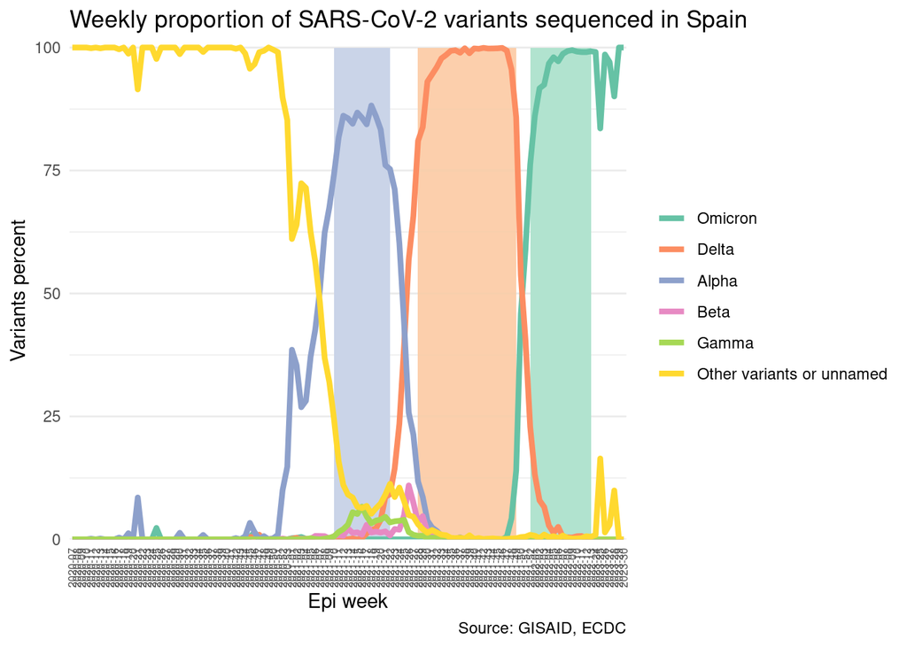

### Option B

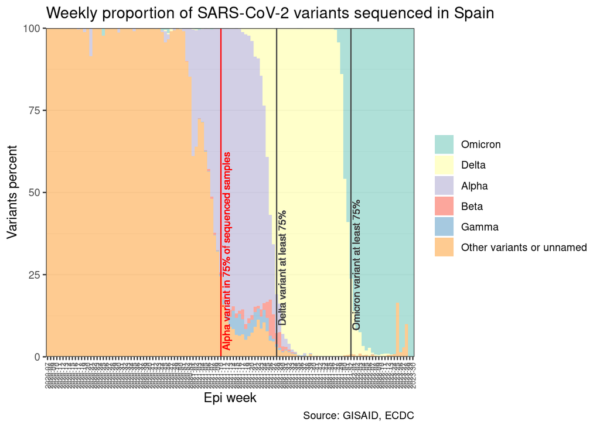

## Plots for vaccine effectiveness sub-analyses

### SUB-A1: Vaccine effectiveness by number of vaccine doses (segregated by variant period and age group)

Groups manually excluded:

- Cases before alpha rise, 60 years old or above, with more than one vaccine dose.
- All cases before alpha rise, younger than 60 years.
- Cases during alpha predominance, 60 years old or above, with three vaccine doses.
- All cases during alpha predominance, younger than 60 years.
- Cases during delta predominance, younger than 60 years, with three vaccine doses.

Groups automatically excluded:

- Those with upper vaccine effectiveness estimation interval above 100%.
- Those with lower vaccine effectiveness estimation interval below 0%.
- Those with vaccine effectiveness point-estimate above 100% or below 0%.

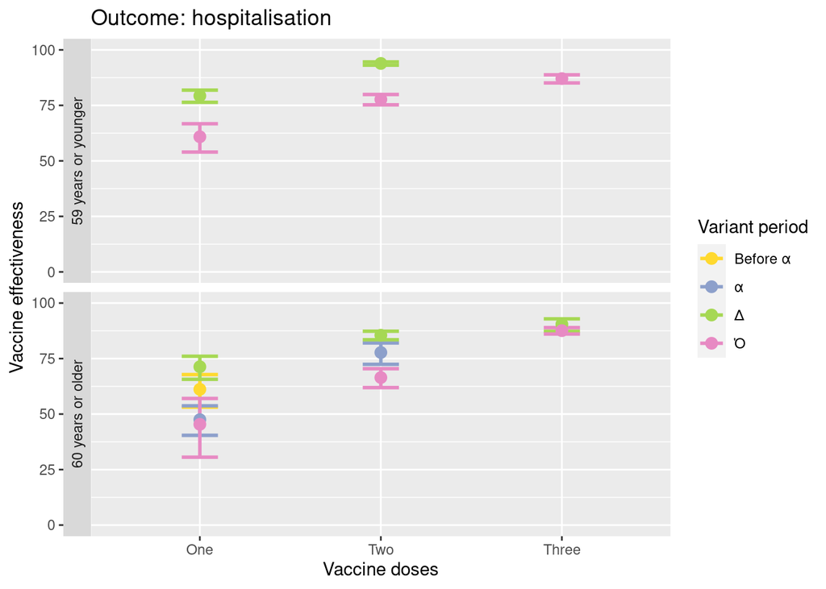

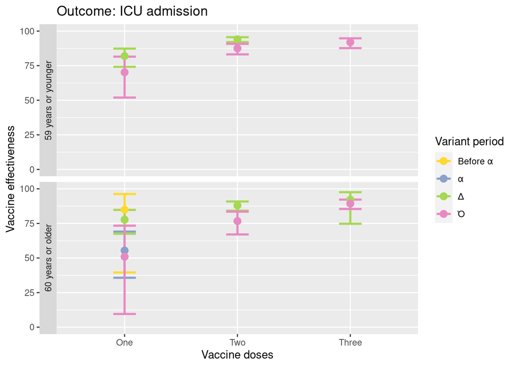

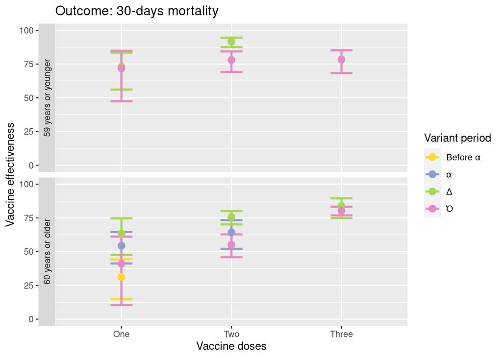

### SUB-A2: NO MANUAL FILTERS Vaccine effectiveness by number of vaccine doses (segregated by variant period and age group)

Groups automatically excluded:

- Those with upper vaccine effectiveness estimation interval above 100%.
- Those with lower vaccine effectiveness estimation interval below 0%.
- Those with vaccine effectiveness point-estimate above 100% or below 0%.

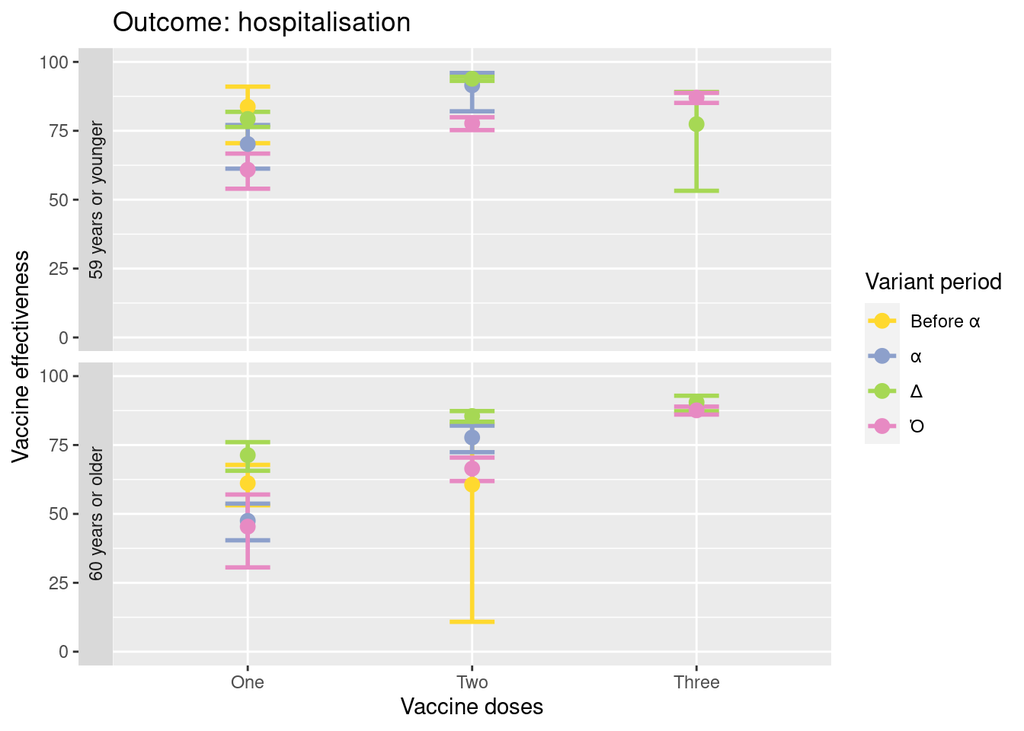

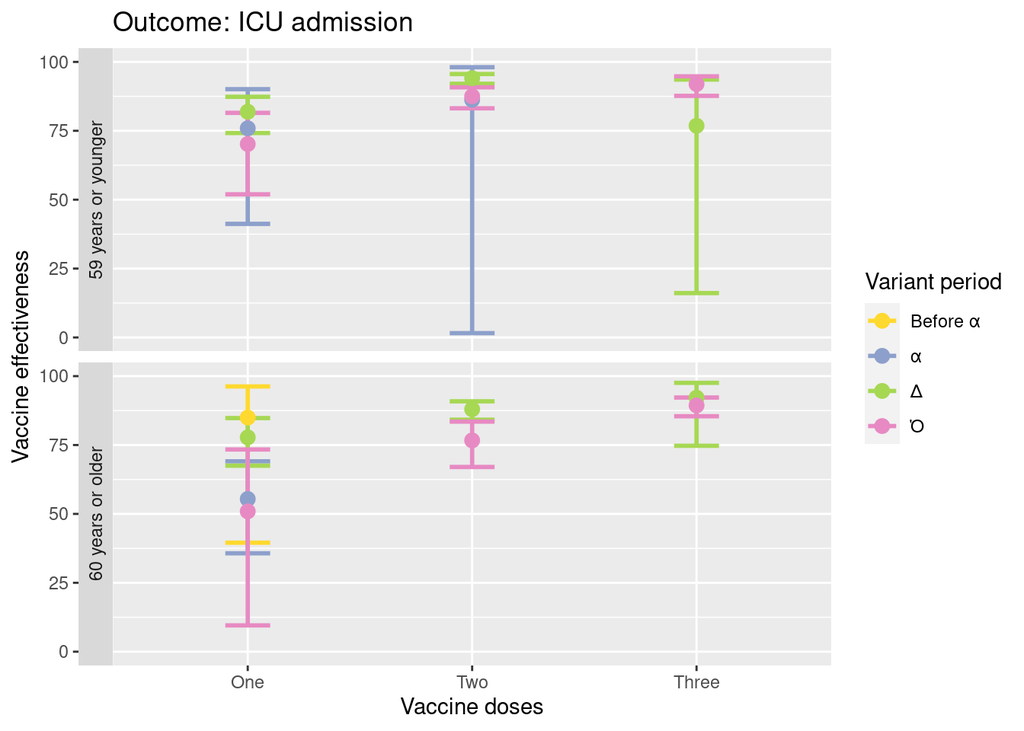

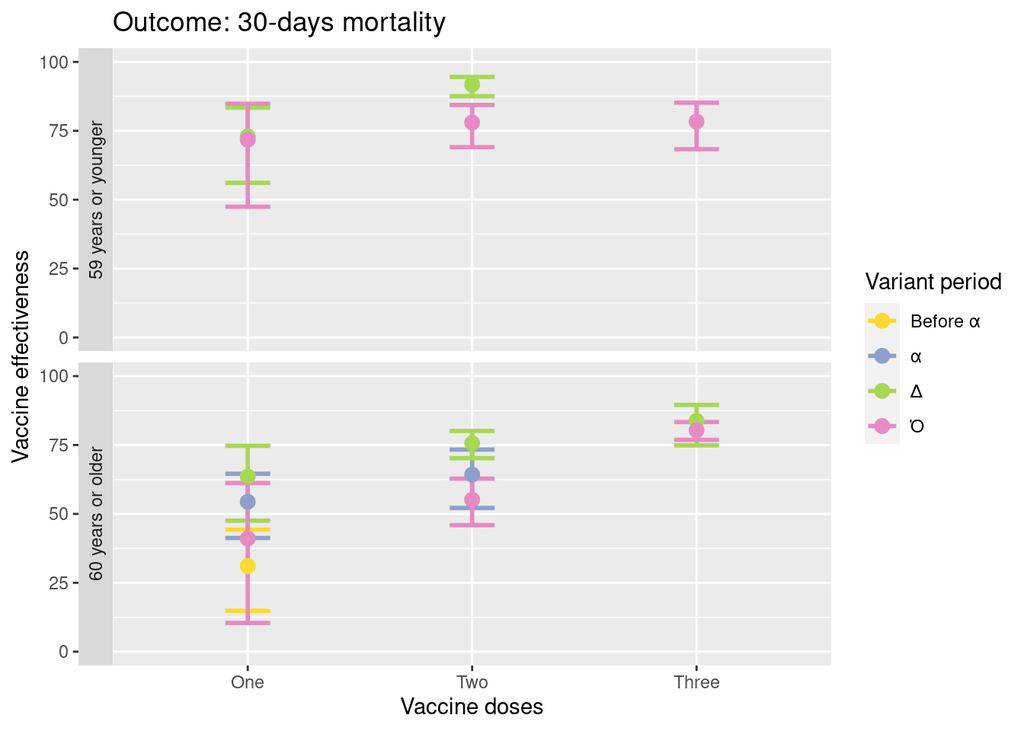

### SUB-B1: Vaccine effectiveness by time since last exposure: infection/vaccination (segregated by variant period and age group)

Groups manually excluded:

- All cases before alpha rise, younger than 60 years.
- All cases during alpha predominance, younger than 60 years.

Groups automatically excluded:

- Those with upper vaccine effectiveness estimation interval above 100%.
- Those with lower vaccine effectiveness estimation interval below 0%.
- Those with vaccine effectiveness point-estimate above 100% or below 0%.

**These analysis and plots are not suitable, since they are trying to portray vaccine effectiveness parametres that have been calculated on variables related to risk, not protection (as opposite to vaccine doses).**

```r
var_agegr_LASTIMMUN %>%
  filter(outcome == "hospitalisation") %>%
  filter(
    (original_model == "Before_60")
    | (original_model == "α_60")
    | (original_model == "Δ_Menor")
    | (original_model == "Δ_60")
    | original_model %in% c("Ό_60", "Ό_Menor")
  ) %>%
  filter(veffec_lower > 0 & veffec_lower <= 100) %>%
  filter(veffec_upper > 0 & veffec_upper <= 100) %>%
  filter(veffec > 0 & veffec < 100) %>%
  ggplot() +
  geom_errorbar(
    aes(x = predictor, ymin = veffec_lower, ymax = veffec_upper, colour = variant),
    linewidth = 1,
    width = 0.2
  ) +
  geom_point(aes(x = predictor, y = veffec, colour = variant), size = 3) +
  facet_wrap(~agegroup, nrow = 2, strip.position = "left") +
  scale_colour_manual(values = colours) +
  # scale_y_continuous(limits = c(0, 100)) +
  theme(axis.text.x = element_text(vjust = 0.5)) +
  labs(
    y = "Vaccine effectiveness",
    x = "Time past since last exposure",
    colour = "Variant period",
    title = "Outcome: hospitalisation"
  )



var_agegr_LASTIMMUN %>%
  filter(outcome == "intensivecare") %>%
  filter(
    (original_model == "Before_60")
    | (original_model == "α_60")
    | (original_model == "Δ_Menor")
    | (original_model == "Δ_60")
    | original_model %in% c("Ό_60", "Ό_Menor")
  ) %>%
  filter(veffec_lower > 0 & veffec_lower <= 100) %>%
  filter(veffec_upper > 0 & veffec_upper <= 100) %>%
  filter(veffec > 0 & veffec < 100) %>%
  ggplot() +
  geom_errorbar(
    aes(x = predictor, ymin = veffec_lower, ymax = veffec_upper, colour = variant),
    linewidth = 1,
    width = 0.2
  ) +
  geom_point(aes(x = predictor, y = veffec, colour = variant), size = 3) +
  facet_wrap(~agegroup, nrow = 2, strip.position = "left") +
  scale_colour_manual(values = colours) +
  scale_y_continuous(limits = c(0, 100)) +
  theme(axis.text.x = element_text(vjust = 0.5)) +
  labs(
    y = "Vaccine effectiveness",
    x = "Time past since last exposure",
    colour = "Variant period",
    title = "Outcome: ICU admission"
  )



var_agegr_LASTIMMUN %>%
  filter(outcome == "mortality") %>%
  filter(
    (original_model == "Before_60")
    | (original_model == "α_60")
    | (original_model == "Δ_Menor")
    | (original_model == "Δ_60")
    | original_model %in% c("Ό_60", "Ό_Menor")
  ) %>%
  filter(veffec_lower > 0 & veffec_lower <= 100) %>%
  filter(veffec_upper > 0 & veffec_upper <= 100) %>%
  filter(veffec > 0 & veffec < 100) %>%
  ggplot() +
  geom_errorbar(
    aes(x = predictor, ymin = veffec_lower, ymax = veffec_upper, colour = variant),
    linewidth = 1,
    width = 0.2
  ) +
  geom_point(aes(x = predictor, y = veffec, colour = variant), size = 3) +
  facet_wrap(~agegroup, nrow = 2, strip.position = "left") +
  scale_colour_manual(values = colours) +
  scale_y_continuous(limits = c(0, 100)) +
  theme(axis.text.x = element_text(vjust = 0.5)) +
  labs(
    y = "Vaccine effectiveness",
    x = "Time past since last exposure",
    colour = "Variant period",
    title = "Outcome: 30-days mortality"
  )
```

### SUB-B2: NO MANUAL FILTERS Vaccine effectiveness by time since last exposure: infection/vaccination (segregated by variant period and age group)

Groups automatically excluded:

- Those with upper vaccine effectiveness estimation interval above 100%.
- Those with lower vaccine effectiveness estimation interval below 0%.
- Those with vaccine effectiveness point-estimate above 100% or below 0%.

**These analysis and plots are not suitable, since they are trying to portray vaccine effectiveness parametres that have been calculated on variables related to risk, not protection (as opposite to vaccine doses).**

```r
var_agegr_LASTIMMUN %>%
  filter(outcome == "hospitalisation") %>%
  # filter(
  #   (original_model == "Before_60")
  #   | (original_model == "α_60")
  #   | (original_model == "Δ_Menor")
  #   | (original_model == "Δ_60")
  #   | original_model %in% c("Ό_60", "Ό_Menor")
  # ) %>%
  filter(veffec_lower > 0 & veffec_lower <= 100) %>%
  filter(veffec_upper > 0 & veffec_upper <= 100) %>%
  filter(veffec > 0 & veffec < 100) %>%
  ggplot() +
  geom_errorbar(
    aes(x = predictor, ymin = veffec_lower, ymax = veffec_upper, colour = variant),
    linewidth = 1,
    width = 0.2
  ) +
  geom_point(aes(x = predictor, y = veffec, colour = variant), size = 3) +
  facet_wrap(~agegroup, nrow = 2, strip.position = "left") +
  scale_colour_manual(values = colours) +
  scale_y_continuous(limits = c(0, 100)) +
  theme(axis.text.x = element_text(vjust = 0.5)) +
  labs(
    y = "Vaccine effectiveness",
    x = "Time past since last exposure",
    colour = "Variant period",
    title = "Outcome: hospitalisation"
  )



var_agegr_LASTIMMUN %>%
  filter(outcome == "intensivecare") %>%
  # filter(
  #   (original_model == "Before_60")
  #   | (original_model == "α_60")
  #   | (original_model == "Δ_Menor")
  #   | (original_model == "Δ_60")
  #   | original_model %in% c("Ό_60", "Ό_Menor")
  # ) %>%
  filter(veffec_lower > 0 & veffec_lower <= 100) %>%
  filter(veffec_upper > 0 & veffec_upper <= 100) %>%
  filter(veffec > 0 & veffec < 100) %>%
  ggplot() +
  geom_errorbar(
    aes(x = predictor, ymin = veffec_lower, ymax = veffec_upper, colour = variant),
    linewidth = 1,
    width = 0.2
  ) +
  geom_point(aes(x = predictor, y = veffec, colour = variant), size = 3) +
  facet_wrap(~agegroup, nrow = 2, strip.position = "left") +
  scale_colour_manual(values = colours) +
  scale_y_continuous(limits = c(0, 100)) +
  theme(axis.text.x = element_text(vjust = 0.5)) +
  labs(
    y = "Vaccine effectiveness",
    x = "Time past since last exposure",
    colour = "Variant period",
    title = "Outcome: ICU admission"
  )



var_agegr_LASTIMMUN %>%
  filter(outcome == "mortality") %>%
  # filter(
  #   (original_model == "Before_60")
  #   | (original_model == "α_60")
  #   | (original_model == "Δ_Menor")
  #   | (original_model == "Δ_60")
  #   | original_model %in% c("Ό_60", "Ό_Menor")
  # ) %>%
  # filter(veffec_lower > 0 & veffec_lower <= 100) %>%
  filter(veffec_upper > 0 & veffec_upper <= 100) %>%
  filter(veffec > 0 & veffec < 100) %>%
  ggplot() +
  geom_errorbar(
    aes(x = predictor, ymin = veffec_lower, ymax = veffec_upper, colour = variant),
    linewidth = 1,
    width = 0.2
  ) +
  geom_point(aes(x = predictor, y = veffec, colour = variant), size = 3) +
  facet_wrap(~agegroup, nrow = 2, strip.position = "left") +
  scale_colour_manual(values = colours) +
  scale_y_continuous(limits = c(0, 100)) +
  theme(axis.text.x = element_text(vjust = 0.5)) +
  labs(
    y = "Vaccine effectiveness",
    x = "Time past since last exposure",
    colour = "Variant period",
    title = "Outcome: 30-days mortality"
  )
```

### SUB-B1 v2!: *Risk of infection* by time since last exposure: infection/vaccination (segregated by variant period and age group)

Groups manually excluded:

- All cases before alpha rise, younger than 60 years.
- All cases during alpha predominance, younger than 60 years.

Groups automatically excluded:

- Those with OR point-estimate above 10.

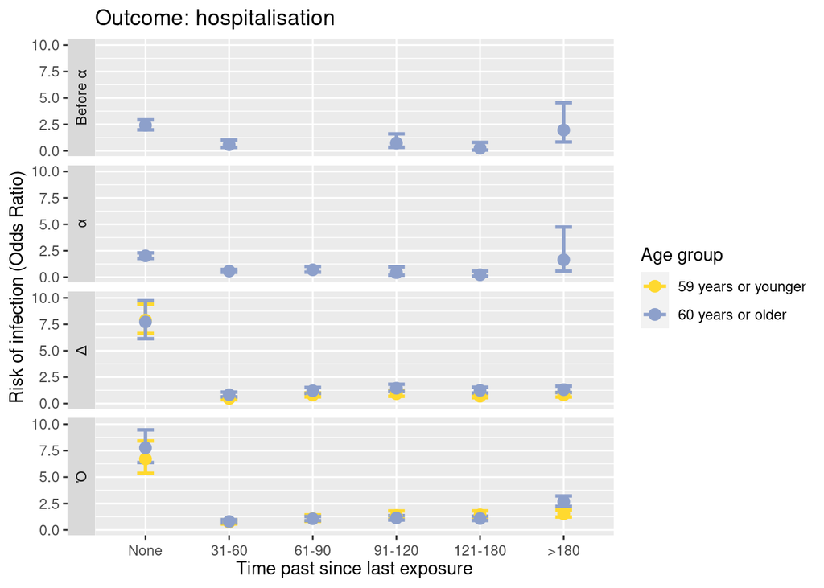

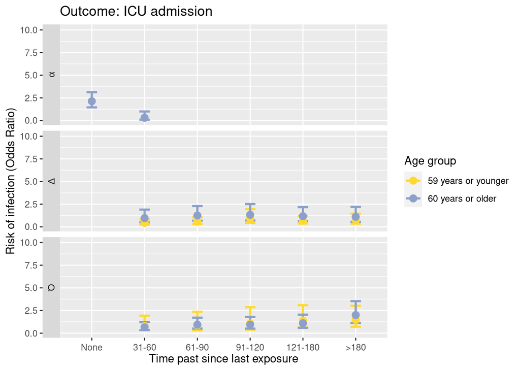

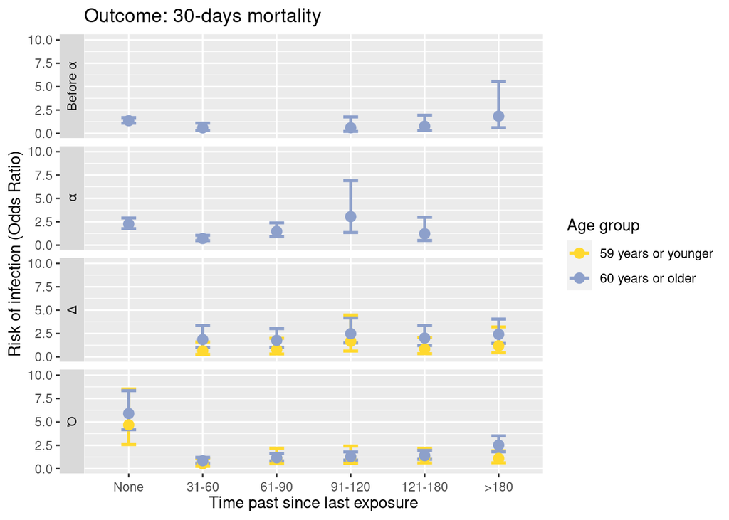

### SUB-B2 v2!: NO MANUAL FILTERS *Risk of infection* by time since last exposure: infection/vaccination (segregated by variant period and age groups)

Groups automatically excluded:

- Those with OR point-estimate above 10.

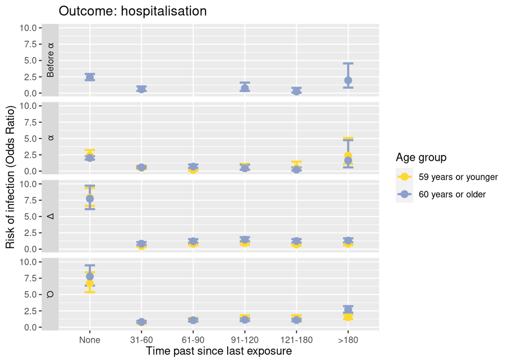

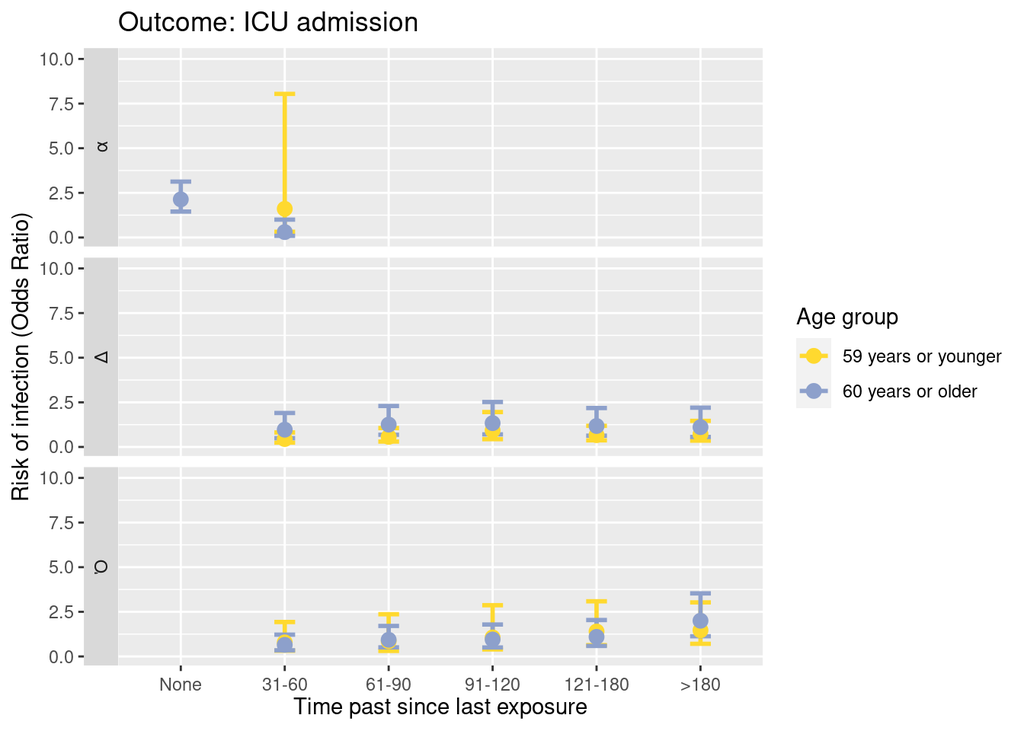

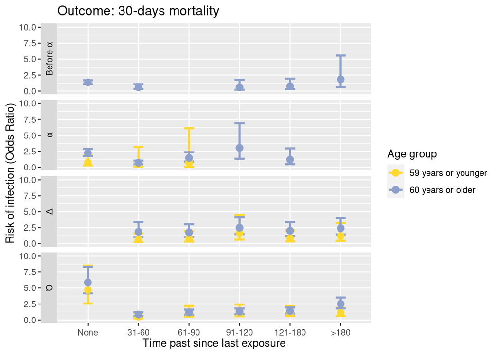

### Risk of infection by time since last exposure (segregated by number of vaccine doses and age groups)

Groups automatically excluded:

- Those with OR point-estimate above 10.

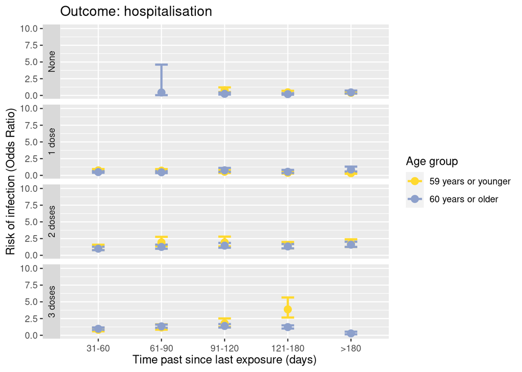

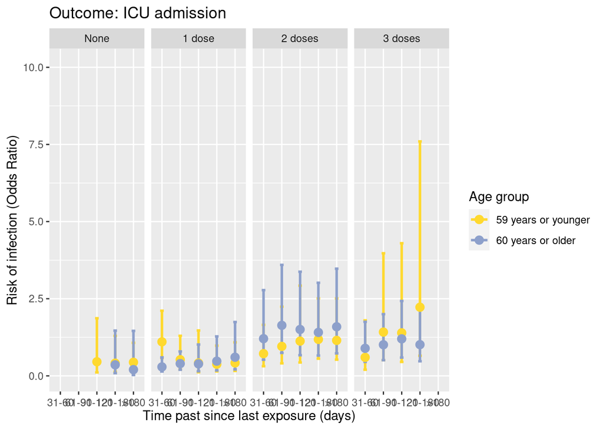

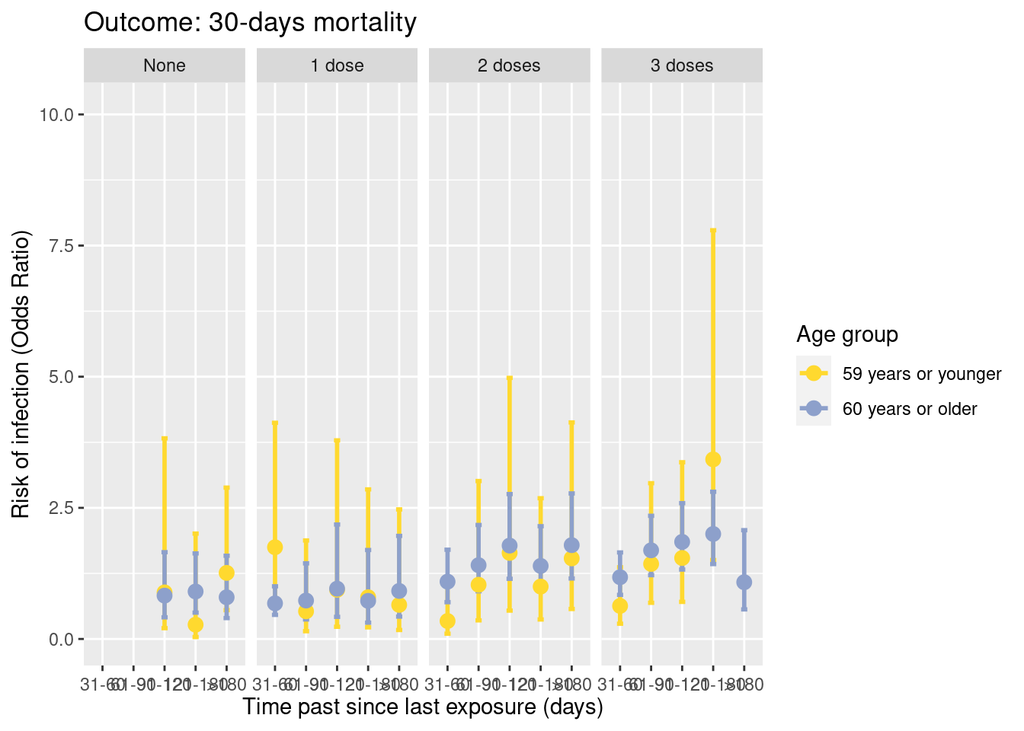

### ALTERNATIVE!! PREDICTOR: time past since last exposure (subset by nº of doses)

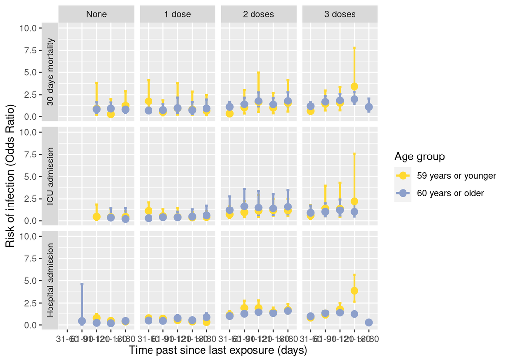

# Upset Plot for describing categories

```r
# upset(data=vacunas, intersections = NOM_VACUNA,group.by = COD_NUHSA_ENCRIPTADO, order.by = "freq")
```

# Sankey Plots

## Data Load

```r
# Read final dataset file
# estudio_vacunas_t_final_selected <-
#   readRDS(file = "/opt/datos_compartidos/vacunas_data/Rfiles/estudio_vacunas_t_final_selected.rds")
# nrow(estudio_vacunas_t_final_selected)
# summary(estudio_vacunas_t_final_selected$pautas_covid)


# Vaccinated and unvaccinated population before positive CODIV-19 infection by RT-PCR
# vacunados <-
#   estudio_vacunas_t_final_selected %>%
#   filter(pautas_covid %in% c("1", "2", "3", "4")) %>%
#   nrow()
# vacunados

# no_vacunados <-
#   estudio_vacunas_t_final_selected %>%
#   filter(pautas_covid %in% c("0")) %>%
#   nrow()
# no_vacunados

# Hospital admission data
# vacunados_ingresados <-
#   estudio_vacunas_t_final_selected %>%
#   filter(pautas_covid %in% c("1", "2", "3", "4")
#          & hosp_stay_bin == 1) %>%
#   nrow()
# vacunados_ingresados

# vacunados_no_ingresados <-
#   estudio_vacunas_t_final_selected %>%
#   filter(pautas_covid %in% c("1", "2", "3", "4")
#          & hosp_stay_bin == 0) %>%
#   nrow()
# vacunados_no_ingresados

# no_vacunados_ingresados <-
#   estudio_vacunas_t_final_selected %>%
#   filter(pautas_covid %in% c("0")
#          & hosp_stay_bin == 1) %>%
#   nrow()
# no_vacunados_ingresados

# no_vacunados_no_ingresados <-
#   estudio_vacunas_t_final_selected %>%
#   filter(pautas_covid %in% c("0")
#          & hosp_stay_bin == 0) %>%
#   nrow()
# no_vacunados_no_ingresados


# UCI admission data
# vacunados_ingresados_uci <-
#   estudio_vacunas_t_final_selected %>%
#   filter(pautas_covid %in% c("1", "2", "3", "4")
#          & icu_stay_bin == 1) %>%
#   nrow()
# vacunados_ingresados_uci

# vacunados_no_ingresados_uci <-
  # estudio_vacunas_t_final_selected %>%
  # filter(pautas_covid %in% c("1", "2", "3", "4")
         # & icu_stay_bin == 0) %>%
  # nrow()
# vacunados_no_ingresados_uci

# no_vacunados_ingresados_uci <-
  # estudio_vacunas_t_final_selected %>%
  # filter(pautas_covid %in% c("0")
         # & icu_stay_bin == 1) %>%
  # nrow()
# no_vacunados_ingresados_uci

# no_vacunados_no_ingresados_uci <-
  # estudio_vacunas_t_final_selected %>%
  # filter(pautas_covid %in% c("0")
         # & icu_sta/opt/datos_compartidos/vacunas_data/tablas/groups by nvac & lastimmun (logreg vaccines only, & variant)y_bin == 0) %>%
  # nrow()
# no_vacunados_no_ingresados_uci


# Mortality data
# vacunados_muertos <-
  # estudio_vacunas_t_final_selected %>%
  # filter(pautas_covid %in% c("1", "2", "3", "4")
         # & mortality30d == 1) %>%
  # nrow()
# vacunados_muertos

# vacunados_vivos <-
  # estudio_vacunas_t_final_selected %>%
  # filter(pautas_covid %in% c("1", "2", "3", "4")
         # & mortality30d == 0) %>%
  # nrow()
# vacunados_vivos

# no_vacunados_muertos <-
  # estudio_vacunas_t_final_selected %>%
  # filter(pautas_covid %in% c("0")
         # & mortality30d == 1) %>%
  # nrow()
# no_vacunados_muertos

# no_vacunados_vivos <-
  # estudio_vacunas_t_final_selected %>%
  # filter(pautas_covid %in% c("0")
         # & mortality30d == 0) %>%
  # nrow()
# no_vacunados_vivos
```

## Sankey Plot for Hospital Admission

```r
#Name of nodes
# A <- "Población de estudio"
# B <- "Vacunados"
# C <- "No Vacunados"
# D <- "No Hospitalizados"
# E <- "Hospitalizados"

# Make a connection data frame
# source <- c(A, A, B, B, C, C)
# target <- c(B, C, D, E, D, E)
# value <- c(vacunados, no_vacunados, vacunados_no_ingresados, vacunados_ingresados, no_vacunados_no_ingresados, no_vacunados_ingresados)
# data <- data.frame(source, target, value)

# From these flows we need to create a node data frame: it lists every entities involved in the flow
# nodes <-
#   data.frame("name" = c(
#     as.character(data$source),
#     as.character(data$target)
#     %>% unique()
#   ))

# With networkD3, connection must be provided using id, not using real name like in the links dataframe. So we need to reformat it.
# data$IDsource <- match(data$source, nodes$name) - 1
# data$IDtarget <- match(data$target, nodes$name) - 1


## Add link types for coloring purpose
# data$group = as.factor(c("type_0",
#                          "type_0",
#                          "type_1",
#                          "type_2",
#                          "type_1",
#                          "type_2"))

# Add a 'group' column to each node.
# nodes$group <-
#   as.factor(
#     c(
#       "node1",
#       "node1",
#       "node2",
#       "node2",
#       "node3",
#       "node3",
#       "node2",
#       "node3",
#       "node4",
#       "node5"
#     )
#   )

# Give a color for each group
# my_color <-
#   'd3.scaleOrdinal() .domain(["type_0", "type_1", "type_2", "node1", "node2", "node3", "node4", "node5"]) .range(["#a4b0be", "#7bed9f", "#ff6b81", "#747d8c", "#70a1ff", "#eccc68", "#2ed573", "#ff4757"])'

# Create the Sankey diagram
# SankeyDiagram <- sankeyNetwork(
#   Links = data,
#   Nodes = nodes,
#   Source = "IDsource",
#   Target = "IDtarget",
#   Value = "value",
#   NodeID = "name",
#   colourScale = my_color,
#   LinkGroup = "group",
#   NodeGroup = "group",
#   fontSize = 16,
#   fontFamily = 34,
#   nodeWidth = 100,
#   nodePadding = 20,
#   height = 400,
#   width = 1100,
#   iterations = 32,
#   sinksRight = FALSE
# )

# Print the Sankey diagram
# SankeyDiagram
```

## Sankey Plot for UCI Admission

```r
#Name of nodes
# A <- "Población de estudio"
# B <- "Vacunados"
# C <- "No Vacunados"
# G <- "No Ingresados en UCI"
# H <- "Ingresados en UCI"

# Make a connection data frame
# source <- c(A, A, B, B, C, C)
# target <- c(B, C, G, H, G, H)
# value <- c(vacunados, no_vacunados, vacunados_no_ingresados_uci, vacunados_ingresados_uci, no_vacunados_no_ingresados_uci, no_vacunados_ingresados_uci)
# data <- data.frame(source, target, value)

# From these flows we need to create a node data frame: it lists every entities involved in the flow
# nodes <-
#   data.frame("name" = c(
#     as.character(data$source),
#     as.character(data$target)
#     %>% unique()
#   ))

# With networkD3, connection must be provided using id, not using real name like in the links dataframe. So we need to reformat it.
# data$IDsource <- match(data$source, nodes$name) - 1
# data$IDtarget <- match(data$target, nodes$name) - 1


## Add link types for coloring purpose
# data$group = as.factor(c("type_0",
#                          "type_0",
#                          "type_1",
#                          "type_2",
#                          "type_1",
#                          "type_2"))

# Add a 'group' column to each node.
# nodes$group <-
#   as.factor(
#     c(
#       "node1",
#       "node1",
#       "node2",
#       "node2",
#       "node3",
#       "node3",
#       "node2",
#       "node3",
#       "node4",
#       "node5"
#     )
#   )

# Give a color for each group
# my_color <-
#   'd3.scaleOrdinal() .domain(["type_0", "type_1", "type_2", "node1", "node2", "node3", "node4", "node5"]) .range(["#a4b0be", "#7bed9f", "#ff6b81", "#747d8c", "#70a1ff", "#eccc68", "#2ed573", "#ff4757"])'

# Create the Sankey diagram
# SankeyDiagram <- sankeyNetwork(
#   Links = data,
#   Nodes = nodes,
#   Source = "IDsource",
#   Target = "IDtarget",
#   Value = "value",
#   NodeID = "name",
#   colourScale = my_color,
#   LinkGroup = "group",
#   NodeGroup = "group",
#   fontSize = 16,
#   fontFamily = 34,
#   nodeWidth = 100,
#   nodePadding = 20,
#   height = 400,
#   width = 1100,
#   iterations = 32,
#   sinksRight = FALSE
# )

# Print the Sankey diagram
# SankeyDiagram
```

## Sankey Plot for Survival/Mortality

```r
#Name of nodes
# A <- "Población de estudio"
# B <- "Vacunados"
# C <- "No Vacunados"
# I <- "Supervivientes"
# J <- "Fallecidos"

# Make a connection data frame
# source <- c(A, A, B, B, C, C)
# target <- c(B, C, I, J, I, J)
# value <- c(vacunados, no_vacunados, vacunados_vivos, vacunados_muertos, no_vacunados_vivos, no_vacunados_muertos)
# data <- data.frame(source, target, value)

# From these flows we need to create a node data frame: it lists every entities involved in the flow
# nodes <-
#   data.frame("name" = c(
#     as.character(data$source),
#     as.character(data$target)
#     %>% unique()
#   ))

# With networkD3, connection must be provided using id, not using real name like in the links dataframe. So we need to reformat it.
# data$IDsource <- match(data$source, nodes$name) - 1
# data$IDtarget <- match(data$target, nodes$name) - 1


## Add link types for coloring purpose
# data$group = as.factor(c("type_0",
#                          "type_0",
#                          "type_1",
#                          "type_2",
#                          "type_1",
#                          "type_2"))

# Add a 'group' column to each node.
# nodes$group <-
#   as.factor(
#     c(
#       "node1",
#       "node1",
#       "node2",
#       "node2",
#       "node3",
#       "node3",
#       "node2",
#       "node3",
#       "node4",
#       "node5"
#     )
#   )

# Give a color for each group
# my_color <-
#   'd3.scaleOrdinal() .domain(["type_0", "type_1", "type_2", "node1", "node2", "node3", "node4", "node5"]) .range(["#a4b0be", "#7bed9f", "#ff6b81", "#747d8c", "#70a1ff", "#eccc68", "#2ed573", "#ff4757"])'

# Create the Sankey diagram
# SankeyDiagram <- sankeyNetwork(
#   Links = data,
#   Nodes = nodes,
#   Source = "IDsource",
#   Target = "IDtarget",
#   Value = "value",
#   NodeID = "name",
#   colourScale = my_color,
#   LinkGroup = "group",
#   NodeGroup = "group",
#   fontSize = 16,
#   fontFamily = 34,
#   nodeWidth = 100,
#   nodePadding = 20,
#   height = 400,
#   width = 1100,
#   iterations = 32,
#   sinksRight = FALSE
# )

# Print the Sankey diagram
# SankeyDiagram
```

# Rentabilidad Edad

```r
# Definir los parámetros
# costo_hospitalizacion <- 4612.76
# precio_vacuna <- 31
# dosis_equiv <- 148
# nnt <- 148
# red_abs_riesgo <- 0.0068

# Definir un vector de edades de 18 a 120
# edades <- 18:120

# Calcular la rentabilidad para cada edad
# rentabilidad <- (costo_hospitalizacion/dosis_equiv) / nnt / (1 - red_abs_riesgo)

# Crear un dataframe con los resultados
# df <- data.frame(edad = edades, rentabilidad = rentabilidad)
```